# Chapter 4 Principal Component Analysis: Computer Lab Solutions

Richard Wilkinson

### Q1

Using the `iris` dataset, familiarize yourself with the `prcomp` command and its output.

```r
head(iris) # always look at the data first.
```

|  | Sepal.Length | Sepal.Width | Petal.Length | Petal.Width | Species |
| --- | --- | --- | --- | --- | --- |
| 1 | 5.1 | 3.5 | 1.4 | 0.2 | setosa |
| 2 | 4.9 | 3.0 | 1.4 | 0.2 | setosa |
| 3 | 4.7 | 3.2 | 1.3 | 0.2 | setosa |
| 4 | 4.6 | 3.1 | 1.5 | 0.2 | setosa |
| 5 | 5.0 | 3.6 | 1.4 | 0.2 | setosa |
| 6 | 5.4 | 3.9 | 1.7 | 0.4 | setosa |

```r
X<- as.matrix(iris[,1:4])
X.pca <- prcomp(X)
print(X.pca)
```

```
## Standard deviations (1, .., p=4):
## [1] 2.0562689 0.4926162 0.2796596 0.1543862
##
## Rotation (n x k) = (4 x 4):
##                      PC1         PC2         PC3        PC4
## Sepal.Length  0.36138659 -0.65658877  0.58202985  0.3154872
## Sepal.Width  -0.08452251 -0.73016143 -0.59791083 -0.3197231
## Petal.Length  0.85667061  0.17337266 -0.07623608 -0.4798390
## Petal.Width   0.35828920  0.07548102 -0.54583143  0.7536574
```

```r
summary(X.pca)
```

```
## Importance of components:
##                           PC1     PC2    PC3     PC4
## Standard deviation     2.0563 0.49262 0.2797 0.15439
## Proportion of Variance 0.9246 0.05307 0.0171 0.00521
## Cumulative Proportion  0.9246 0.97769 0.9948 1.00000
```

This has done PCA on the covariance matrix. The print command prints out the eigenvectors and the square root of the eigenvalues. To instead to PCA on the correlation matrix use:

```r
prcomp(X, scale=TRUE) # uses correlation matrix
```

We can access the individual components as follows:

```r
X.pca$sdev  # the square root of the eigenvecotrs
```

```
## [1] 2.0562689 0.4926162 0.2796596 0.1543862
```

```r
X.pca$rotation ## the loadings/eigenvectors
```

```
##                      PC1         PC2         PC3        PC4
## Sepal.Length  0.36138659 -0.65658877  0.58202985  0.3154872
## Sepal.Width  -0.08452251 -0.73016143 -0.59791083 -0.3197231
## Petal.Length  0.85667061  0.17337266 -0.07623608 -0.4798390
## Petal.Width   0.35828920  0.07548102 -0.54583143  0.7536574
```

```r
X.pca$center  # the sample mean
```

```
## Sepal.Length  Sepal.Width Petal.Length  Petal.Width
##     5.843333     3.057333     3.758000     1.199333
```

```r
X.pca$scale # TRUE if correlation matrix used, or FALSE if covariance matrix used.
```

```
## [1] FALSE
```

```r
head(X.pca$x)  # the scores
```

```
##            PC1        PC2         PC3          PC4
## [1,] -2.684126 -0.3193972  0.02791483  0.002262437
## [2,] -2.714142  0.1770012  0.21046427  0.099026550
## [3,] -2.888991  0.1449494 -0.01790026  0.019968390
## [4,] -2.745343  0.3182990 -0.03155937 -0.075575817
## [5,] -2.728717 -0.3267545 -0.09007924 -0.061258593
## [6,] -2.280860 -0.7413304 -0.16867766 -0.024200858
```

- Now, instead of using `prcomp` we will do the analysis ourselves using the `eigen` command.
- Start by computing the sample mean and sample variance of the dataset (use $n-1$ as the denominator when you compute the sample variance to get the same answer as provided by `prcomp`).

```r
xbar = colMeans(X)
cov(X)
```

```
##              Sepal.Length Sepal.Width Petal.Length Petal.Width
## Sepal.Length    0.6856935  -0.0424340    1.2743154   0.5162707
## Sepal.Width    -0.0424340   0.1899794   -0.3296564  -0.1216394
## Petal.Length    1.2743154  -0.3296564    3.1162779   1.2956094
## Petal.Width     0.5162707  -0.1216394    1.2956094   0.5810063
```

```r
Xcent = sweep(X,2,xbar) # HX
S = t(Xcent)%*%Xcent/149 # should agree with cov(X)
```

- Now compute the eigenvalues and eigenvectors of the covariance matrix using `eigen`. Check that these agree with those computed by `prcomp` (noting that `prcomp` returns the standard deviation which is the square root of the eigenvalues).

```r
(S.eig = eigen(S))
```

```
## eigen() decomposition
## $values
## [1] 4.22824171 0.24267075 0.07820950 0.02383509
##
## $vectors
##             [,1]        [,2]        [,3]       [,4]
## [1,]  0.36138659  0.65658877 -0.58202985  0.3154872
## [2,] -0.08452251  0.73016143  0.59791083 -0.3197231
## [3,]  0.85667061 -0.17337266  0.07623608 -0.4798390
## [4,]  0.35828920 -0.07548102  0.54583143  0.7536574
```

```r
X.pca$rotation -S.eig$vectors
```

```
##                        PC1        PC2        PC3           PC4
## Sepal.Length  1.665335e-16 -1.3131775  1.1640597 -3.330669e-16
## Sepal.Width   0.000000e+00 -1.4603229 -1.1958217 -5.551115e-16
## Petal.Length -1.110223e-16  0.3467453 -0.1524722  5.551115e-17
## Petal.Width   5.551115e-17  0.1509620 -1.0916629 -3.330669e-16
```

What has gone wrong - why don’t they agree? Two things have happened. Firstly there are small numerical errors that occur due to rounding errors. The second is that the eigenvectors are only determined upto multiplication by $\pm 1$. If we divide them, we can see they are essentially the same:

```r
X.pca$rotation/S.eig$vectors
```

```
##              PC1 PC2 PC3 PC4
## Sepal.Length   1  -1  -1   1
## Sepal.Width    1  -1  -1   1
## Petal.Length   1  -1  -1   1
## Petal.Width    1  -1  -1   1
```

Let’s check the standard deviations agree with the eigenvalues, and that the scores (transformed variables) agree:

```r
X.pca$sdev^2
```

```
## [1] 4.22824171 0.24267075 0.07820950 0.02383509
```

```r
S.eig$values
```

```
## [1] 4.22824171 0.24267075 0.07820950 0.02383509
```

```r
X.pca$sdev^2- S.eig$values
```

```
## [1]  1.776357e-15  1.665335e-16  4.163336e-17 -1.318390e-16
```

```r
scores = Xcent%*%S.eig$vectors
## note must use Xcent!

head(X.pca$x/ scores)
```

```
##      PC1 PC2 PC3 PC4
## [1,]   1  -1  -1   1
## [2,]   1  -1  -1   1
## [3,]   1  -1  -1   1
## [4,]   1  -1  -1   1
## [5,]   1  -1  -1   1
## [6,]   1  -1  -1   1
```

- Now we will do the same thing again, but using the `svd` command.

Let’s first create a column centred and scaled version of the data $\frac{1}{\sqrt{n-1}}\mathbf H\mathbf X$. Note that if we scale $X$ we scale the singular values by the same amount, and that scaling $X$ doesn’t change the singular vectors.

```r
Xtilde = Xcent/sqrt(149)
svd(Xtilde)$d - svd(Xcent)$d/sqrt(149)
```

```
## [1]  4.440892e-16  1.665335e-16  2.220446e-16 -5.551115e-17
```

```r
#Singular values of
#HX/sqrt(149) = sqrt(eigenvalues S)

# scaling X doesn't change the singular vectors
head(svd(Xcent)$v/svd(Xtilde)$v )
```

```
##      [,1] [,2] [,3] [,4]
## [1,]    1    1    1    1
## [2,]    1    1    1    1
## [3,]    1    1    1    1
## [4,]    1    1    1    1
```

```r
#head(svd(Xcent)$u/svd(Xtilde)$u)
```

Let’s check the singular values agree with the standard deviations computed by `prcomp`:

```r
svd(Xtilde)$d - X.pca$sdev
```

```
## [1]  4.440892e-16  1.665335e-16  2.220446e-16 -5.551115e-17
```

```r
svd(Xcent)$d/sqrt(149) - X.pca$sdev # this is what R does
```

```
## [1] 0 0 0 0
```

Finally, let’s check the scores agree by doing both $\mathbf H\mathbf X\mathbf V$ and $\mathbf U\boldsymbol{\Sigma}$, where
$$\mathbf H\mathbf X= \mathbf U\boldsymbol{\Sigma}\mathbf V^\top$$
is the SVD of $\mathbf H\mathbf X$.

```r
scores = Xcent%*% svd(Xcent)$v
head(scores/X.pca$x)
```

```
##      PC1 PC2 PC3 PC4
## [1,]   1   1   1   1
## [2,]   1   1   1   1
## [3,]   1   1   1   1
## [4,]   1   1   1   1
## [5,]   1   1   1   1
## [6,]   1   1   1   1
```

```r
#U Sigma
head(svd(Xcent)$u %*% diag(svd(Xcent)$d)/X.pca$x)
```

```
##      PC1 PC2 PC3 PC4
## [1,]   1   1   1   1
## [2,]   1   1   1   1
## [3,]   1   1   1   1
## [4,]   1   1   1   1
## [5,]   1   1   1   1
## [6,]   1   1   1   1
```

```r
# Note that this is using Sigma for HX
#not HX/sqrt(n)
```

### Q2

In this question we will look at the crabs data from the `MASS` R package. Start by selecting the relevant columns:

```r
library(MASS)
?crabs # look at the help page.
X = crabs[,4:8]
```

Carry out PCA on the data in $X$ using the covariance matrix, including obtaining a scree plot and plotting the PC scores.

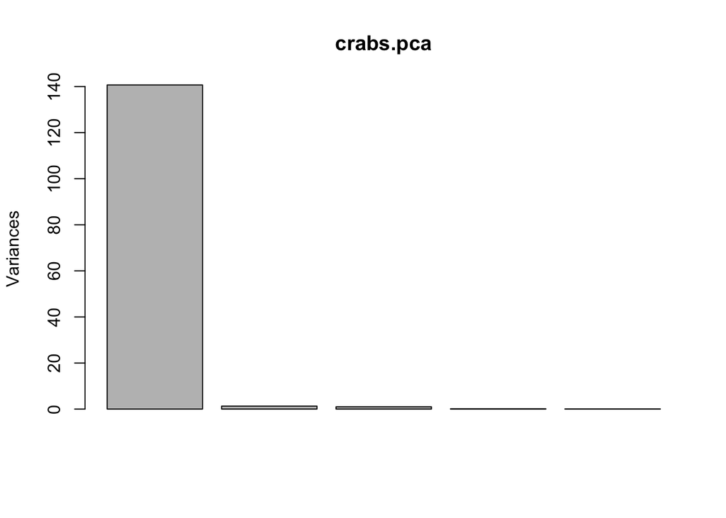

```r
crabs.pca <- prcomp(X) # do PCA
plot(crabs.pca) # scree plot
```

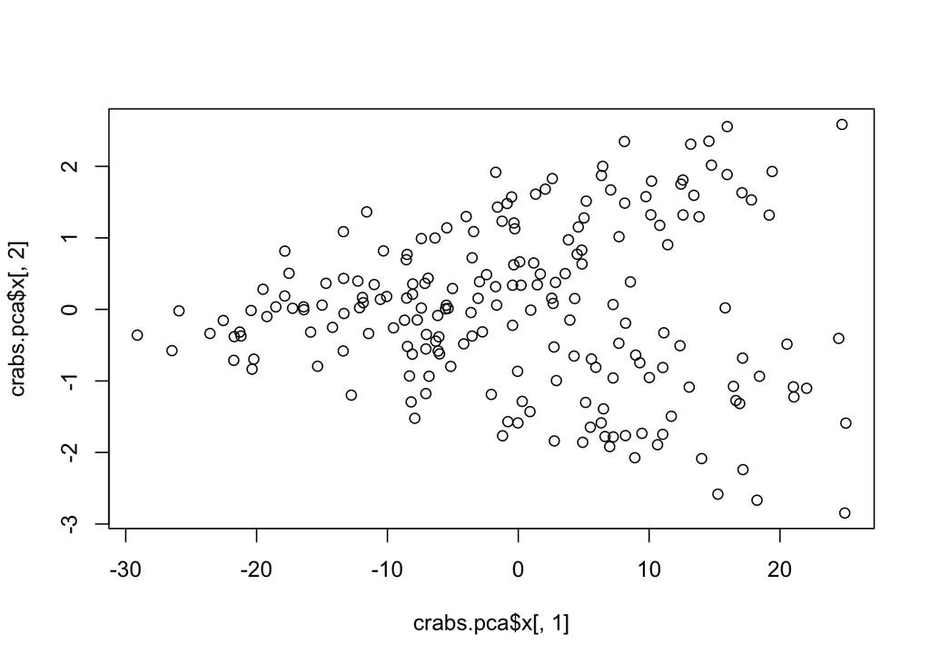

```r
plot(crabs.pca$x[,1], crabs.pca$x[,2]) # PC2 vs PC1.
```

By adding colour we can see some patterns. The easiest way is to install the ggfortify package.

```r
library(ggfortify)
```

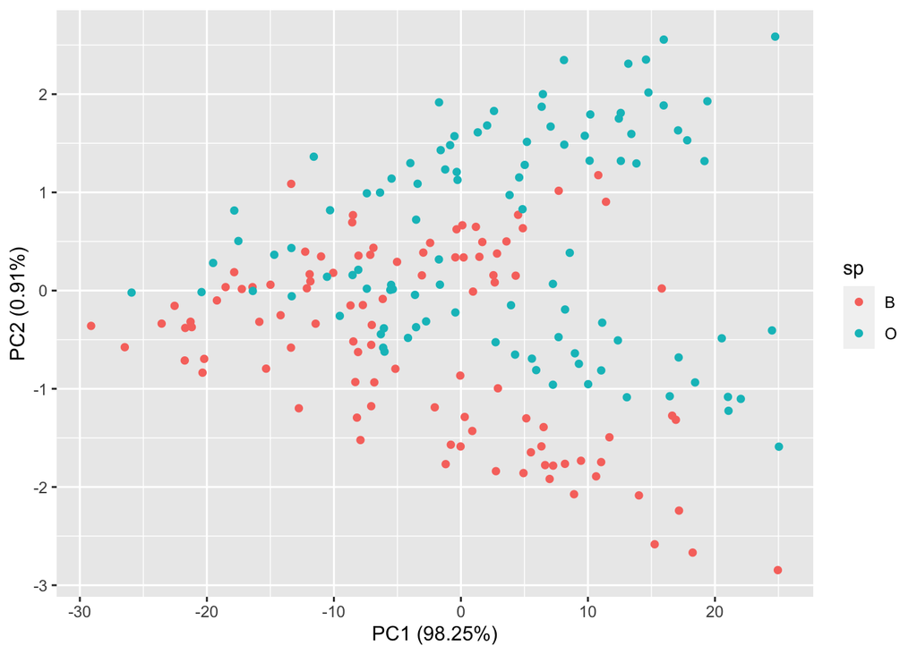

```r
#autoplot(crabs.pca, data = crabs, scale=FALSE)
# This does the same as above.

autoplot(crabs.pca, data = crabs, colour='sp', scale=FALSE)
```

This has coloured the points by species. We can see there is clearly a difference between blue and orange crabs (confusingly coloured opposite to their name here).

If we colour by species and change the shape according to sex, we can see distinct clusters.

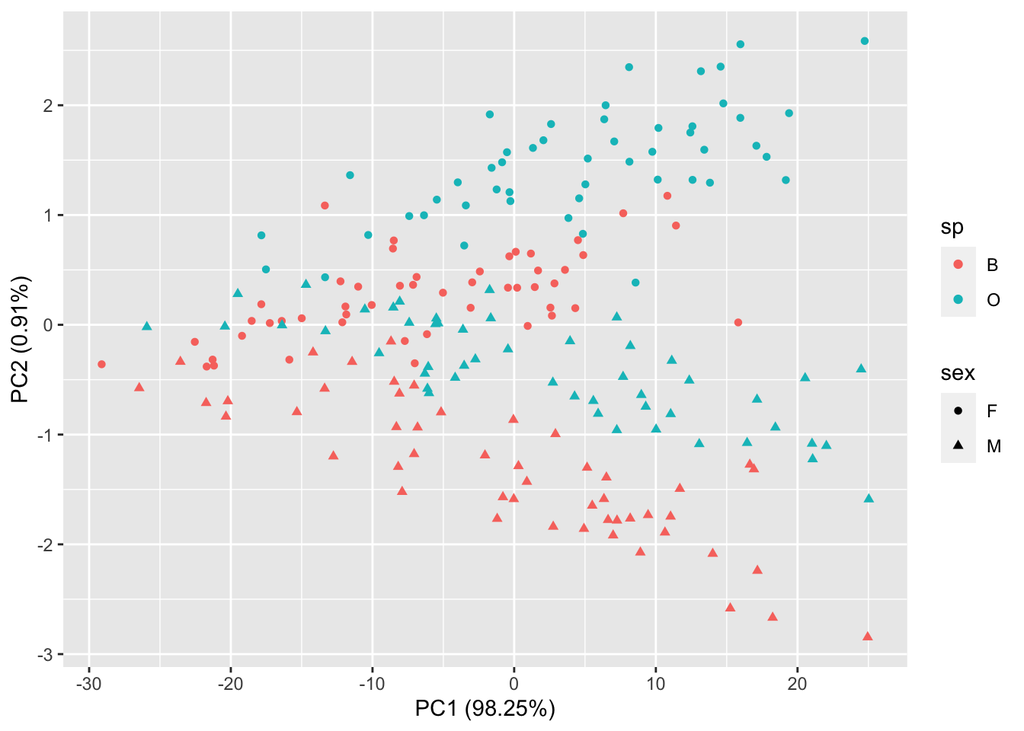

```r
autoplot(crabs.pca, data = crabs, colour='sp', scale=FALSE, shape='sex')
```

Do you have any suggestions for an interpretation for the 1st PC? 2nd PC?

The first PC appears to be a measure of size, primarily carapace size:

```r
crabs.pca$rotation[,1]
```

```
##        FL        RW        CL        CW        BD
## 0.2889810 0.1972824 0.5993986 0.6616550 0.2837317
```

The second PC measures FL and RW vs carapace size.

```r
crabs.pca$rotation[,2]
```

```
##         FL         RW         CL         CW         BD
##  0.3232500  0.8647159 -0.1982263 -0.2879790  0.1598447
```

There is a clear sex dependence here; female crabs have higher positive PC2 score (corresponding to big FL, RW, BD, and smaller Carapace).

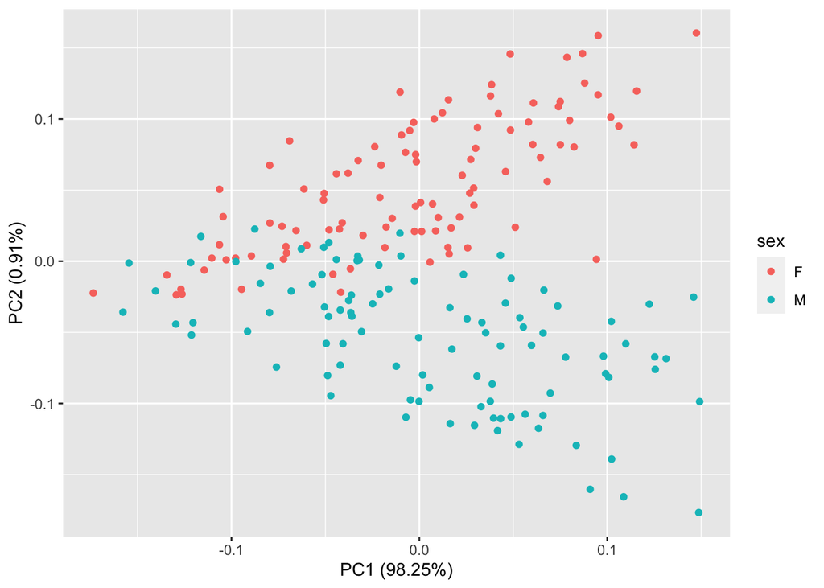

```r
autoplot(crabs.pca, data = crabs, colour='sex')
```

Do you think an analysis based on the sample covariance matrix ${\bf S}$ or the correlation matrix ${\bf R}$ is preferable with this dataset?

This doesn’t make a big difference but does alter the interpretations a little.

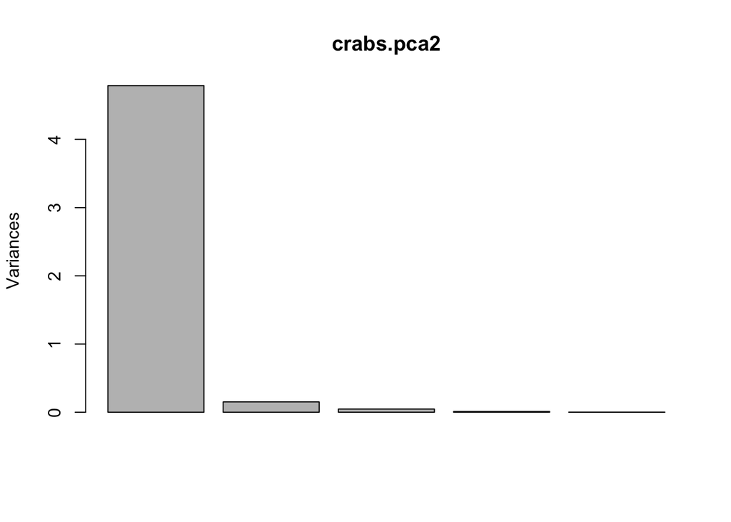

```r
crabs.pca2 <- prcomp(X, scale=TRUE) # Use the correlation matrix.
plot(crabs.pca2)
```

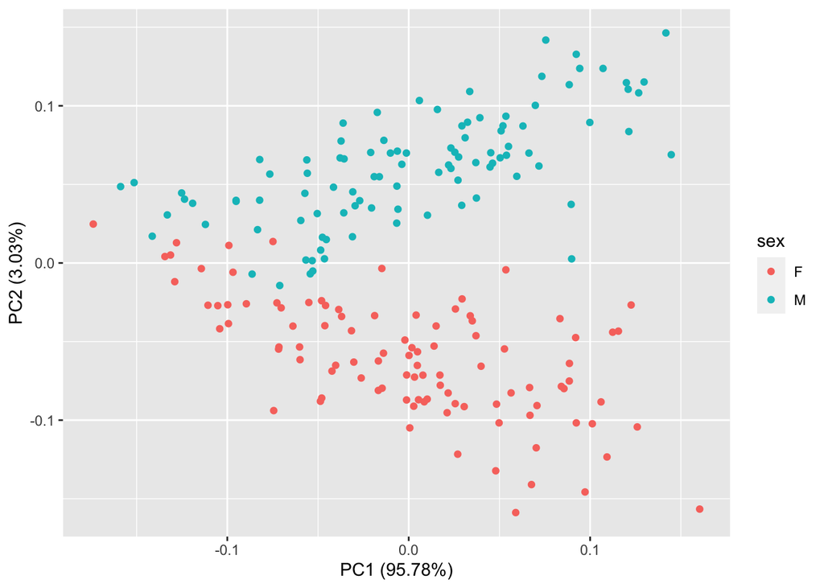

```r
autoplot(crabs.pca2, data = crabs, colour='sex')
```

```r
# not a big change
```

PC1 is still a measure of size, but now evenly weights across all attributes. PC2 is changed from the unscaled PCA, and it now measures the difference in RW to the other attributes.

```r
crabs.pca2$rotation[,1]
```

```
##        FL        RW        CL        CW        BD
## 0.4520437 0.4280774 0.4531910 0.4511127 0.4511336
```

```r
crabs.pca2$rotation[,2]
```

```
##         FL         RW         CL         CW         BD
##  0.1375813 -0.8981307  0.2682381  0.1805959  0.2643219
```

Another way to interpret the PCs is to look at circle

```r
library(factoextra) # you will need to install this first time you use it.
```

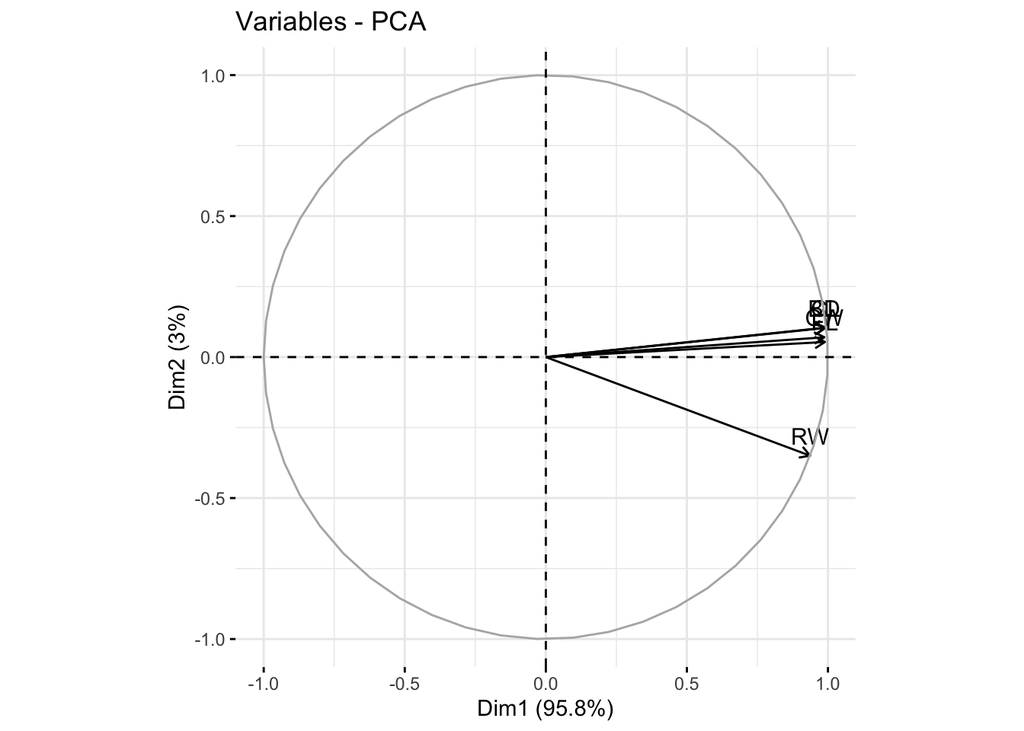

```r
fviz(crabs.pca2, element='var')
```

This gives the correlation between the first two transformed variables and the original variables.

```r
cor(cbind(crabs.pca2$x[,1:2], X))[3:7,1:2]
```

```
##          PC1         PC2
## FL 0.9892256  0.05358348
## RW 0.9367791 -0.34979304
## CL 0.9917363  0.10447013
## CW 0.9871883  0.07033629
## BD 0.9872340  0.10294487
```

Why is it plotted on a circle? It is possible to show that
$$\sum_{j=1}^p {\mathbb{C}\operatorname{or}}(y_j, x_i)^2 = 1$$
where $x_i$ are the original variables, and $y_j$ the transformed variables.

Thus for any of the original variables $x_i$ we have that
$${\mathbb{C}\operatorname{or}}(y_1, x_i)^2+{\mathbb{C}\operatorname{or}}(y_2, x_i)^2 \leq 1$$
i.e., they lie within a circle.

We can do similar plots for the unscaled version of PCA. But now we’re plotting variances and so these points do not lie in a cirle.

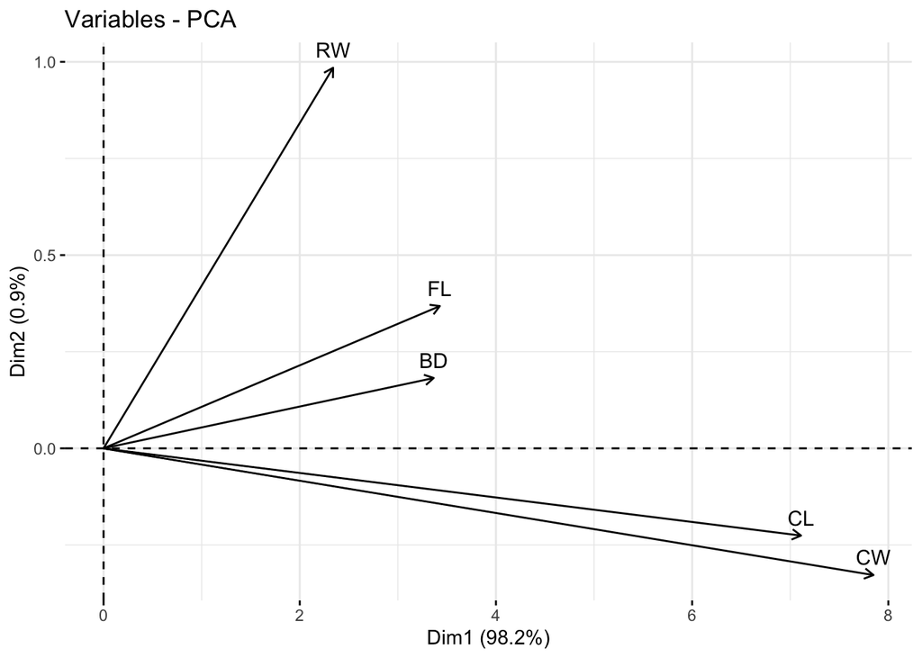

```r
fviz(crabs.pca, element='var')
```

So we can see again that in the unscaled case, PC1 is a measure of overall size, but particularly CL and CW. PC2 is RW, FL, BD versus CL and CW.

- Without doing any computation, think about what you expect the sample mean and sample covariance matrix to be for the PC scores. Check this numerically.

We’d expect the sample mean of the scores to be 0 and the sample variance to equal the eigenvalues

```r
colMeans(crabs.pca$x)
```

```
##           PC1           PC2           PC3           PC4           PC5
##  2.496892e-15 -1.325676e-15  1.469987e-15  1.422473e-16  1.053099e-15
```

```r
apply(crabs.pca$x,2, sd)
```

```
##        PC1        PC2        PC3        PC4        PC5
## 11.8619441  1.1387874  1.0001346  0.3678306  0.2791312
```

```r
crabs.pca$sdev
```

```
## [1] 11.8619441  1.1387874  1.0001346  0.3678306  0.2791312
```

```r
cov(crabs.pca$x)# diagonal,
```

```
##              PC1           PC2           PC3           PC4           PC5
## PC1 1.407057e+02  1.966270e-14  2.569605e-15  5.194082e-15  4.783155e-14
## PC2 1.966270e-14  1.296837e+00  1.287455e-16 -1.593400e-16 -3.615803e-16
## PC3 2.569605e-15  1.287455e-16  1.000269e+00 -9.137737e-17  9.489234e-17
## PC4 5.194082e-15 -1.593400e-16 -9.137737e-17  1.352993e-01  1.929003e-17
## PC5 4.783155e-14 -3.615803e-16  9.489234e-17  1.929003e-17  7.791423e-02
```

```r
#i.e. uncorrelated scores

sum(crabs.pca$sdev^2)
```

```
## [1] 143.216
```

```r
sum(diag(cov(X)))  #trace of covariance matrix
```

```
## [1] 143.216
```

```r
prod(crabs.pca$sdev^2)
```

```
## [1] 1.924094
```

```r
det(cov(X))
```

```
## [1] 1.924094
```

- Try the following transformations of the data…. Check the effect of each transformation on the principal components (the loadings/eigenvectors), the principal component scores, and the variance of the principal components (the eigenvalues).

Add a constant to each columns of X

```r
X2 = sweep(X,2, c(1,2,3,4,5), FUN="+")
#check
colMeans(X)
```

```
##      FL      RW      CL      CW      BD
## 15.5830 12.7385 32.1055 36.4145 14.0305
```

```r
colMeans(X2)
```

```
##      FL      RW      CL      CW      BD
## 16.5830 14.7385 35.1055 40.4145 19.0305
```

```r
#check its not changed anything
head(prcomp(X2)$x/crabs.pca$x)
```

```
##   PC1 PC2 PC3 PC4 PC5
## 1   1   1   1   1   1
## 2   1   1   1   1   1
## 3   1   1   1   1   1
## 4   1   1   1   1   1
## 5   1   1   1   1   1
## 6   1   1   1   1   1
```

Scale by a diagonal matrix. This does change the scores, loadings and variance in the unscaled PCA, but not if we use the scaled PCA.

```r
X3 = as.matrix(X) %*% diag(1:5)
# unscaled PCA
head(prcomp(X3)$x/crabs.pca$x)
```

```
##        PC1         PC2        PC3       PC4         PC5
## 1 3.501570 -2.90825484  -2.482006 59.635776  -0.4526624
## 2 3.528576 -0.73714597  -3.795646  2.002687   1.1752732
## 3 3.509788  2.20071465  18.954783 -4.137683  -1.1601186
## 4 3.513644  0.70733356  -8.179958 -0.456134 -10.2513676
## 5 3.534282  0.41827889  -4.778195  4.095140   0.6088965
## 6 3.475948  0.09625112 -17.735177  3.472802   1.3192753
```

```r
prcomp(X3)$sdev/crabs.pca$sdev
```

```
## [1] 3.534903 3.399749 2.274241 2.675349 1.641119
```

```r
prcomp(X3)$rotation/crabs.pca$rotation
```

```
##            PC1         PC2          PC3        PC4        PC5
## [1,] 0.2819620  0.43176573  0.151237898  0.2135542 -7.7777053
## [2,] 0.5620376  0.02340064 -2.331722289 -1.3521470 -0.8578779
## [3,] 0.8487397 -0.48003534 -1.413070627 -5.5847934 -0.2241656
## [4,] 1.1324711  1.83358040 -0.032304663 -3.1220422 -0.1593389
## [5,] 1.4132958  5.20510558  0.003762158  0.5861264  0.2127435
```

```r
# scaled PCA
head(prcomp(X3, scale=TRUE)$x/crabs.pca2$x)
```

```
##   PC1 PC2 PC3 PC4 PC5
## 1   1   1   1   1   1
## 2   1   1   1   1   1
## 3   1   1   1   1   1
## 4   1   1   1   1   1
## 5   1   1   1   1   1
## 6   1   1   1   1   1
```

```r
prcomp(X3, scale=TRUE)$sdev/crabs.pca2$sdev
```

```
## [1] 1 1 1 1 1
```

```r
prcomp(X3, scale=TRUE)$rotation/crabs.pca2$rotation
```

```
##      PC1 PC2 PC3 PC4 PC5
## [1,]   1   1   1   1   1
## [2,]   1   1   1   1   1
## [3,]   1   1   1   1   1
## [4,]   1   1   1   1   1
## [5,]   1   1   1   1   1
```

Orthogonal rotations: if we multiply the data by an orthogonal matrix the scores and eigenvalues remain the same but the loadings/eigenvectors change.

```r
library(pracma)
U <- randortho(5)
X4 = as.matrix(X)%*% U

head(prcomp(X4)$x/crabs.pca$x) # scores are the same
```

```
##   PC1 PC2 PC3 PC4 PC5
## 1   1  -1  -1   1   1
## 2   1  -1  -1   1   1
## 3   1  -1  -1   1   1
## 4   1  -1  -1   1   1
## 5   1  -1  -1   1   1
## 6   1  -1  -1   1   1
```

```r
prcomp(X4)$sdev/crabs.pca$sdev # eigenvalues the same
```

```
## [1] 1 1 1 1 1
```

```r
prcomp(X4)$rotation/crabs.pca$rotation
```

```
##             PC1        PC2        PC3         PC4        PC5
## [1,]  1.6009304  0.8788397  0.5371533  0.44045299  5.8100190
## [2,] -2.3217413 -0.3686425  1.4054612 -0.89158041 -4.0924318
## [3,] -1.1453299 -1.7873351  2.2289108 -3.45224924  0.0926087
## [4,] -0.4802977 -0.9111763 -0.5572355 -6.32667364  0.7456616
## [5,]  0.2195418  4.9391322 -1.0960699  0.03355126 -0.2605094
```

```r
#  loadings/eigenvectors change.
```

### Q3

Download the final Premier League table for the 2018-19 season from https://www.rotowire.com/soccer/league-table.php?season=2018. Repeat the analysis done in the notes.

```r
library(dplyr)
prem1819 <- read.csv('~/Documents/Teaching/MATH3030_4068/ComputerTaskSolutions/prem201819.csv')
# the data can be downloaded from https://www.rotowire.com/soccer/league-table.php
table <- prem1819 %>% dplyr::select(Team, W, D, L, G, GA, GD)
knitr::kable(head(table,10), booktabs = TRUE, escape=FALSE)
```

| Team | W | D | L | G | GA | GD |
| --- | --- | --- | --- | --- | --- | --- |
| Manchester City | 32 | 2 | 4 | 95 | 23 | 72 |
| Liverpool | 30 | 7 | 1 | 89 | 22 | 67 |
| Chelsea | 21 | 9 | 8 | 63 | 39 | 24 |
| Tottenham Hotspur | 23 | 2 | 13 | 67 | 39 | 28 |
| Arsenal | 21 | 7 | 10 | 73 | 51 | 22 |
| Manchester United | 19 | 9 | 10 | 65 | 54 | 11 |
| Wolverhampton | 16 | 9 | 13 | 47 | 46 | 1 |
| Everton | 15 | 9 | 14 | 54 | 46 | 8 |
| Leicester City | 15 | 7 | 16 | 51 | 48 | 3 |
| West Ham United | 15 | 7 | 16 | 52 | 55 | -3 |

```r
tmp = table[,2:7]
rownames(tmp)=table$Team

prem.pca = prcomp(tmp, retx=TRUE, scale=TRUE)
prem.pca$rotation[,1]
```

```
##          W          D          L          G         GA         GD
## -0.4530159  0.1263618  0.4389841 -0.4416512  0.4287649 -0.4552000
```

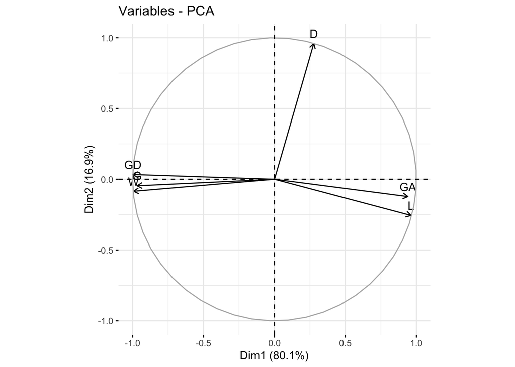

```r
fviz(prem.pca, element='var')
```

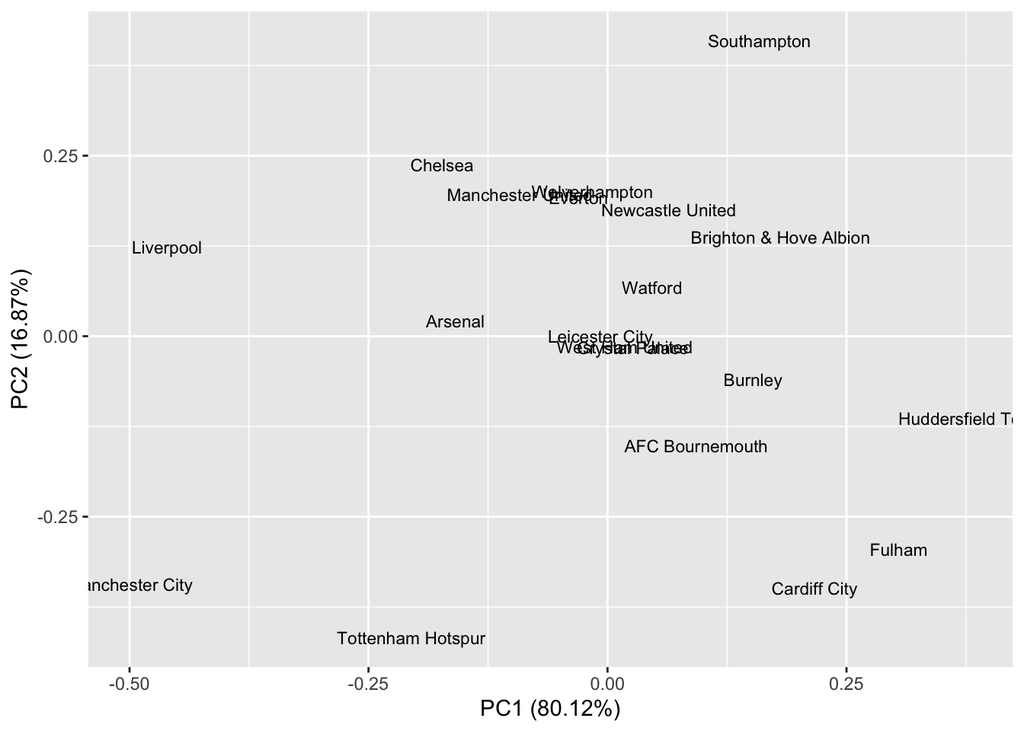

```r
autoplot(prem.pca, data = table,  label = TRUE,  label.size = 3, shape=FALSE)
```

PC1 is remarkably similar to the 2019-20 season. It contrasts goals against and losses vs goals for and wins (ie it measures if the team did well or not). PC2 is mainly measures the number of draws a team had. So Southampton had lots of draws to have a high PC2 score. Manchester city won the lead so have the smallest PC1 score. Huddersfield finished bottom and have the largest PC1 score.